# Running fastOC to identify orthologous gene clusters

# 7 Identify Orthologous Gene Modules

Use the Louvain community detection method to identify groups of genes that are co-expressed within and orthologous across species. The Louvain method is heuristic algorithm and should be run multiple times to reduce noise and incease significance of detected modules[^2].

```r
    nRuns = 100
    results <- louvain(GeneMeta, combined_out, nRuns)
    save(results, file="igraph_louvain.rdata")
```

Remove Louvain communities that have fewer than a minimum number of members. To get an idea of how many genes are assigned to each Louvain community use `hist(colSums(occurance))`,

```r
    occurance <- filterCommunityAssign(results, minMem = 10)
    save(occurance, file = "Occurance_sparse.rdata")
```

Calculate co-appearacnce and perform hierarchical clustering to determine which genes have similar co-appearance. Co-appearance represents how often two genes are assigned to the same Louvain community.

```r
    MultiSpp_trees <- multiSppHclust(occurance, nRuns, GeneMeta)
    save(MultiSpp_trees, file = "MultiSppTrees.rdata")
```

Identify gene modules using dynamic tree cutting.

```r
    MultiSpp_modules <- multiSppModules(MultiSpp_trees, GeneMeta,
         minModuleSize = c(800,800,800),
         cut = c(0.5,0.5,0.5))

    #add module assignemnts to columns 3 of GeneMeta

    GeneMeta[,3]<-do.call(c,lapply(seq_along(MultiSpp_modules), function(y, i) { y[[i]] }, y=MultiSpp_modules))
```

# 8 Visualize Results

In this section, we will create a heatmap plot of the co-appearance results. One major challenge with visualizing these data is the sheer number of genes and visualizing the entire data set is very computationally intense and difficult to render. To get around this, we will sample every ith gene from the gene order defined by the hierarchical cluster step. By default the function `plot_MultiSpp()` samples every 12th gene (sb=12)

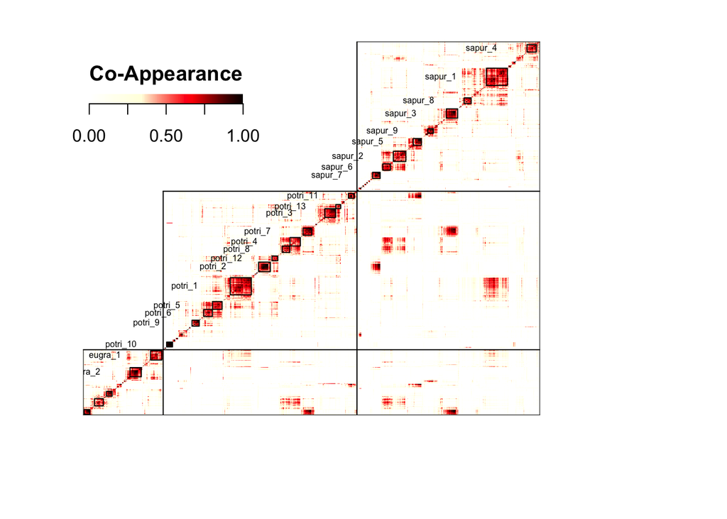

```r
    #Create heatmap of co-appearance modules across all species
    par(fig=c(0,1,0,1))
    plot_MultiSpp(GeneMeta = GeneMeta, order = MultiSpp_trees$order,
                  sb=12, CA_keep = occurance, remove_0 = F, lwd = 1, cex = 0.5)

    #Add heatmap color bar
    par(fig=c(0,0.6,0.6,0.9), new=TRUE)
    color.bar(lut = colorRampPalette(c("white", "lightyellow", "red","black"))(n = 100),
              min = 0, max = 1, nticks=5,
              title = "Co-Appearance")
```

[^1]: Yan K-K, Wang D, Rozowsky J, Zheng H, Cheng C, Gerstein M. 2014. OrthoClust: an orthology-based network framework for clustering data across multiple species. Genome Biology 15(8): R100.
[^2]: Vincent DB, Jean-Loup G, Renaud L, Etienne L. 2008. Fast unfolding of communities in large networks. Journal of Statistical Mechanics: Theory and Experiment 2008(10): P10008.